# Wisconsin Obesity Data

Jessi Kehe

This R Markdown document was adapted from documents created by Professor Bret Larget.

### Setup details

- You will need the packages `tidyverse`, `readxl`, `ggmap`, and `mapproj` for these lectures. Make sure to install them if you haven’t already.
- This assumes you have the R script `viridis.R` two steps back from the working directory (`"../../scripts/viridis.R"`). Be sure to adjust the code if you have this script in a different location.
- The following data files will be used and are assumed to be located two steps back from the working directory in a folder called `data/`. Be sure to adjust the code if you have the data files in a different location.  
  `"../../data/Obesity+Prevalence+by+ZIP+Code+and+Age+Group,+Females.xlsx"`  
  `"../../data/Obesity+Prevalence+by+ZIP+Code+and+Age+Group,+Males.xlsx"`  
  `"../../data/wi_urban_rural.csv"`  
  `"../../data/wi_education.csv"`  
  `"../../data/wi_income.csv"`  
  `"../../data/wi_zip.csv"`

# Lecture: Importing the Obesity data files

### Obesity Data Files

The Wisconsin obesity data is stored in two Excel workbooks, one for females and one for males.

The data for each sex is split across five sheets based on age ranges. Each spread sheet has

- a row for each zip code
- seven columns of data (three of which are derived from counts in the other three)

There is substantial missing data as counts are not reported if they are low by several criteria (which helps to protect patient privacy)

#### Some cautions

> “These prevalence estimates are based on patient populations and reflect those who sought care from participating health care systems during 2015 and 2016. Only individuals who received care during the submitted period were included in these data, and estimates may not accurately reflect the prevalence of obesity in the Wisconsin population.”
- With the missing values and the non-random sampling, we need to be careful about drawing conclusions about the population of Wisconsin from these data.

> “BMI values are based on heights and weights recorded during patient encounters. There are no standard practices for height and weight measurement across health systems and clinics. Some variation may occur in height and weight measurements based on the clothing and/or shoes that a patient wore during their height and weight measurement.”

### Long format versus wide format

There are two primary *conceptual* ways to read in and combine these data.

**longer format**

- the 10 data sets are read in and stacked on top of one another
- add columns to specify sex and age range (for the spreadsheet/sheet combinations)
- a single *case* has the information for a zipcode/sex/age range combination

**wider format**

- the 10 data sets are read in and combined horizontally
- maintain a single row per ZIP code.
- columns would need to be relabeled so that each column name would also include the sex/age range from which it arose

We will demonstrate reading the data into long format and then show how to reformat this into wide format as needed.

### Read, Reformat, and Reshape Obesity Data

To read data from one sheet into a single data frame we could do something like the following.

```r
male_05_17 <-  read_excel(
  "../../data/Obesity+Prevalence+by+ZIP+Code+and+Age+Group,+Males.xlsx",
  sheet=3, skip=5, na=".")
```

- The data for males, aged 5 to 17, are on sheet 3 of the given file
- The first five lines of this file contain title information,  
  line six has the column names, followed by the data
- The data are actually in columns B through H, but `read_excel()` is smart enough by default to ignore empty column A.

Take a quick look at these data.

```r
head(male_05_17)
```

```
## # A tibble: 6 x 7
##   `ZIP\r\nCode` `Obesity\r\nPre… `Number of\r\nP… `Number of\r\nP…
##           <dbl>            <dbl>            <dbl>            <dbl>
## 1         53001             NA                 NA               NA
## 2         53002             15.5               11               71
## 3         53003             NA                 NA               NA
## 4         53004             NA                 NA               NA
## 5         53005             NA                 NA               NA
## 6         53006             NA                 NA               NA
## # … with 3 more variables: `95% Confidence\r\nInterval for
## #   Percent\r\nObese` <chr>, `Percent of Population\r\nwith Valid BMI
## #   (%)` <dbl>, `Population from US\r\nCensus (2011-2015)` <dbl>
```

```r
dim(male_05_17)
```

```
## [1] 774   7
```

Observations:

- given column names are not convenient
- lots of missing values

Below is code that

1. selects the columns with the raw data (we can always compute the others if desired, and this is safer than trusting it is accurate)
2. then renames the columns

This code uses `select()` and `rename()` from `dplyr` along with the select helper functions `starts_with()` and `ends_with()` to avoid typing the long variable names provided.

We use `mutate()` to add columns `sex` and `age` which contain the corresponding values for this spreadsheet/sheet

```r
male_05_17 <- male_05_17 %>%
  select(starts_with("ZIP"),
         starts_with("Number"),
         starts_with("Population")) %>%
  rename(zip = starts_with("ZIP"),
         obese = ends_with("Obesity"),
         bmi = ends_with("BMI"),
         pop = starts_with("Population")) %>%
  mutate(sex = "male") %>%
  mutate(age = "5-17")

head(male_05_17)
```

```
## # A tibble: 6 x 6
##     zip obese   bmi   pop sex   age
##   <dbl> <dbl> <dbl> <dbl> <chr> <chr>
## 1 53001    NA    NA   164 male  5-17
## 2 53002    11    71   211 male  5-17
## 3 53003    NA    NA     5 male  5-17
## 4 53004    NA    NA   400 male  5-17
## 5 53005    NA    NA  1782 male  5-17
## 6 53006    NA    NA   176 male  5-17
```

```r
rm(male_05_17)
```

#### Combining

To finish creating the data set in long format, we could copy/paste/edit the previous code  
for all 10 sheets and then use `bind_rows()` to combine into a single data frame

A better way,is to write a function for the repeated elements of code.

This results in code that is more concise,  
easier to read, easier to edit, and more clear.

The cost is a bit of new syntax where we introduce the `for()` loop.

The only parts of the previous code that vary when we read different sheets are:  
the file name, the sheet number, and the values for `sex` and `age`.

The next function `read_and_format()` takes as arguments the name of the Excel file, a string which is either “female” or “male”,  
and an integer `i` from 1 to 5 which indicates which age range we are reading.  
- For example, age range 1 is from 5–17 and is on sheet 3 for both the male and female workbooks.

```r
read_and_format <- function(file,sex_string,i)
{
  age_values <- c("05-17","18-34","35-54","55-74","75-plus")
  foo <- read_excel(file, sheet=i+2, skip=5, na=".") %>%
    select(starts_with("ZIP"),
         starts_with("Number"),
         starts_with("Population")) %>%
    rename(zip = starts_with("ZIP"),
           obese = ends_with("Obesity"),
           bmi = ends_with("BMI"),
           pop = starts_with("Population")) %>%
    mutate(sex = sex_string) %>%
    mutate(age = age_values[i])
  return(foo)
}
```

After defining this function, we write a second function  
which uses two nested for-loops to read the data for all sexes and age ranges,  
combining the data sets as each new one is read in.

- the outer loop goes over the two sexes
- the inner loop goes over the indices of the age ranges

The function creates an initial empty `tibble`.

Each sheet is read into a temporary data frame which is then bound (using `bind_rows()`) to the initial one until the initial one has grown to be the complete data frame.

Note that `bind_rows()` only works when the columns are compatible.

```r
read_obesity <- function()
{
  obesity = tibble()
  sexes = c("female","male")
  files = c("../../data/Obesity+Prevalence+by+ZIP+Code+and+Age+Group,+Females.xlsx",
            "../../data/Obesity+Prevalence+by+ZIP+Code+and+Age+Group,+Males.xlsx")

  for ( s in 1:2 )
  {
    for ( i in 1:5 )
    {
      temp <- read_and_format(files[s],sexes[s],i)
      obesity <- bind_rows(obesity,temp)
    }
  }
  return( obesity )
}
```

Now call the function and save the obesity data as `obesity`.

```r
obesity <- read_obesity()

head(obesity)
```

```
## # A tibble: 6 x 6
##     zip obese   bmi   pop sex    age
##   <dbl> <dbl> <dbl> <dbl> <chr>  <chr>
## 1 53001    NA    NA   151 female 05-17
## 2 53002    11    78   172 female 05-17
## 3 53003    NA    NA     4 female 05-17
## 4 53004    NA    NA   325 female 05-17
## 5 53005    NA    NA  1882 female 05-17
## 6 53006    NA    NA   122 female 05-17
```

```r
dim(obesity)
```

```
## [1] 7740    6
```

The long format data has advantages for many purposes.

- We can easily add new columns such as
  - prevalence of obesity among sampled patients for each zip/sex/age combination
  - the total estimated number of such people in the population.
- We can filter to select certain characteristics (only males, only one age group).
- We can also aggregate (sum over zip codes, sexes, or whatever we want).

But when it comes time to combine these data with another data set that has, say, the median household income by zip code, we may want the data in the wide format.

# Lecture: Importing the Rural/Urban, Education, and Economic data files

### Rural/Urban Data

Population counts by zip code and urban/rural.

```r
ru_orig <- read_csv("../../data/wi_urban_rural.csv")
ru <- read_csv("../../data/wi_urban_rural.csv") %>%
  select(Id2,`Urban:`,Rural) %>%
  rename(zip = Id2,
         urban = `Urban:`,
         rural = Rural) %>%
  mutate(population = rural + urban) %>%
  mutate(p_urban = urban/population)
```

### Education Data

Note in the column names of `edu_orig`, these data provide estimates for a population 25 years and older. This is a different age range than the obesity data.

```r
edu_orig <- read_csv("../../data/wi_education.csv",na=c("(X)","-"))
edu <- edu_orig %>%
  select(Id2, #Zipcode
         contains("bachelor's degree or higher")) %>%
  rename(zip = Id2,
         pct_m_bach = `Percent Males; Estimate; Percent bachelor's degree or higher`,
         pct_f_bach = `Percent Females; Estimate; Percent bachelor's degree or higher`) %>%
  select(-contains("Percent"))
```

### Economic Data

```r
income_orig <- read_csv("../../data/wi_income.csv",na=c("-","**")) # Missing data are indicated by a dash or double asterisk
income <- income_orig %>%
  select(Id2,
         `Number; Estimate; Households`,
         `Median income (dollars); Estimate; Households`) %>%
  rename(zip = Id2,
         households = `Number; Estimate; Households`,
         income = `Median income (dollars); Estimate; Households`)
```

# Lecture: Pivoting to Wider Format

### Transform to Wide Format

The long-format data has three columns that we want to spread across more columns:  
- `obese`, `bmi`, and `pop`

For example, for each zip code, we want columns `obese_female_05-17` through `obese_male_75-plus` and something similar for `bmi` and `pop`.

```r
obesity %>%
  count(sex,age)
```

```
## # A tibble: 10 x 3
##    sex    age         n
##    <chr>  <chr>   <int>
##  1 female 05-17     774
##  2 female 18-34     774
##  3 female 35-54     774
##  4 female 55-74     774
##  5 female 75-plus   774
##  6 male   05-17     774
##  7 male   18-34     774
##  8 male   35-54     774
##  9 male   55-74     774
## 10 male   75-plus   774
```

##### Pivoting

We will use the function `pivot_wider()` from the **tidyr** packages.

A few input are specified:

- `id_col=zip` - with the wider form, zip code is our observation that is currently spread across multiple rows
- `names_from=c(sex,age)` - the values from these variables will be used in the new column names
- `values_from=c(obese,bmi,pop)` - the content of the new columns will be from these variables
- `names_sep="_"` - specify the separator for the new column names

```r
obesity_wide <- obesity %>%
  pivot_wider(
    id_cols=zip,
    names_from=c(sex,age),
    values_from=c(obese,bmi,pop),
    names_sep="_"
    )

head(obesity_wide)
```

```
## # A tibble: 6 x 31
##     zip `obese_female_0… `obese_female_1… `obese_female_3… `obese_female_5…
##   <dbl>            <dbl>            <dbl>            <dbl>            <dbl>
## 1 53001               NA               20               39               51
## 2 53002               11               40               66               90
## 3 53003               NA               NA               NA               NA
## 4 53004               NA               32               48               37
## 5 53005               NA               94              219              342
## 6 53006               NA               NA               13               NA
## # … with 26 more variables: `obese_female_75-plus` <dbl>,
## #   `obese_male_05-17` <dbl>, `obese_male_18-34` <dbl>,
## #   `obese_male_35-54` <dbl>, `obese_male_55-74` <dbl>,
## #   `obese_male_75-plus` <dbl>, `bmi_female_05-17` <dbl>,
## #   `bmi_female_18-34` <dbl>, `bmi_female_35-54` <dbl>,
## #   `bmi_female_55-74` <dbl>, `bmi_female_75-plus` <dbl>,
## #   `bmi_male_05-17` <dbl>, `bmi_male_18-34` <dbl>, `bmi_male_35-54` <dbl>,
## #   `bmi_male_55-74` <dbl>, `bmi_male_75-plus` <dbl>, `pop_female_05-17` <dbl>,
## #   `pop_female_18-34` <dbl>, `pop_female_35-54` <dbl>,
## #   `pop_female_55-74` <dbl>, `pop_female_75-plus` <dbl>,
## #   `pop_male_05-17` <dbl>, `pop_male_18-34` <dbl>, `pop_male_35-54` <dbl>,
## #   `pop_male_55-74` <dbl>, `pop_male_75-plus` <dbl>
```

# Lecture: Joining the Data Frames

### Join

To join the obesity data set to the education, income, and rural/urban data sets, we will use the function `left_join()` from `dplyr`.

This function is a *mutating join* function that combines data frames by adding new variables (like `mutate()` does).

In a `left_join()`, the result will keep all of the data in the first (left) data frame and add all the new variables from the second data frame, matching values using the variable specified by the `by` argument.

Typically, the same name is used as the matching variable in each data frame, but this can be modified with a different `by` argument (e.g., `by = c("zip" = "zipcode")` if the matching variables were `zip` for one data frame and `zipcode` for the other)

```r
## Note that obesity has 7740 rows
## (one per zip code/sex/age interval) and the other data frames have
## one row per zip code.
## These columns are replicated as needed to match each row of obesity
obesity <- obesity %>%
  left_join(edu, by="zip") %>%
  left_join(income, by="zip") %>%
  left_join(ru, by="zip")

obesity %>%
  filter(zip == "53001")
```

```
## # A tibble: 10 x 14
##      zip obese   bmi   pop sex   age   pct_m_bach pct_f_bach households income
##    <dbl> <dbl> <dbl> <dbl> <chr> <chr>      <dbl>      <dbl>      <dbl>  <dbl>
##  1 53001    NA    NA   151 fema… 05-17         13         23        788  72206
##  2 53001    20    73   163 fema… 18-34         13         23        788  72206
##  3 53001    39   103   249 fema… 35-54         13         23        788  72206
##  4 53001    51   110   259 fema… 55-74         13         23        788  72206
##  5 53001    NA    NA    55 fema… 75-p…         13         23        788  72206
##  6 53001    NA    NA   164 male  05-17         13         23        788  72206
##  7 53001    12    49   141 male  18-34         13         23        788  72206
##  8 53001    44    86   302 male  35-54         13         23        788  72206
##  9 53001    70   119   239 male  55-74         13         23        788  72206
## 10 53001    NA    NA    73 male  75-p…         13         23        788  72206
## # … with 4 more variables: urban <dbl>, rural <dbl>, population <dbl>,
## #   p_urban <dbl>
```

```r
## Here, both data sets have a row per zip code (there are a few missing rows). Zip codes are matched to add the columns.
obesity_wide <- obesity_wide %>%
  left_join(edu, by="zip") %>%
  left_join(income, by="zip") %>%
  left_join(ru, by="zip")
```

Other mutating join functions are:

- `inner_join()`
  - keep only rows that match in each data frame
- `left_join()`
  - keep all rows from the first data frame
- `right_join()`
  - keep all rows from the second data frame
- `full_join()`
  - keep all rows from both data frames

### Write files

After all of this work, it will be useful to save the data frames into a CSV file which we can read in directly in the future without the need to process all of the excel files.

```r
write_csv(obesity,"../../data/obesity.csv")
write_csv(obesity_wide,"../../data/obesity_wide.csv")
```

# Lecture: Explore Obesity Data

## Read Previously Saved Data

```r
obesity <- read_csv("../../data/obesity.csv") %>%
  mutate(adult = age != "05-17") # indicator for adult
```

### Summarize Obesity

#### Numerical Summaries

> What fraction of Wisconsin residents (aged 5 and older) are obese?

Strategy for the calculation:

- Estimate the fraction of obese people in each zip code by age and sex
- Multiply these fractions by the populations by age and sex
- Sum

```r
## work with obesity data before joining
obesity <- obesity %>%
  mutate(obese_n = pop * (obese/bmi))

obesity %>%
  select(obese_n,pop) %>%
  drop_na() %>%
  summarize(obese_p = sum(obese_n)/sum(pop))
```

```
## # A tibble: 1 x 1
##   obese_p
##     <dbl>
## 1   0.380
```

> What fraction of Wisconsin residents (by sex) are obese?

```r
obesity %>%
  group_by(sex) %>%
  select(obese_n,pop) %>%
  drop_na() %>%
  summarize(obese_p = sum(obese_n)/sum(pop))
```

```
## # A tibble: 2 x 2
##   sex    obese_p
##   <chr>    <dbl>
## 1 female   0.373
## 2 male     0.387
```

> What fraction of Wisconsin residents (by age) are obese?

```r
obesity %>%
  group_by(age) %>%
  select(obese_n,pop) %>%
  drop_na() %>%
  summarize(obese_p = sum(obese_n)/sum(pop))
```

```
## # A tibble: 5 x 2
##   age     obese_p
##   <chr>     <dbl>
## 1 05-17     0.164
## 2 18-34     0.305
## 3 35-54     0.462
## 4 55-74     0.471
## 5 75-plus   0.329
```

> What fraction of Wisconsin residents (by age and sex) are obese?

```r
obesity %>%
  group_by(age,sex) %>%
  select(obese_n,pop) %>%
  drop_na() %>%
  summarize(obese_p = sum(obese_n)/sum(pop)) %>%
  pivot_wider(id_cols=age, names_from=sex, values_from=obese_p)
```

```
## # A tibble: 5 x 3
## # Groups:   age [5]
##   age     female  male
##   <chr>    <dbl> <dbl>
## 1 05-17    0.152 0.176
## 2 18-34    0.316 0.292
## 3 35-54    0.447 0.479
## 4 55-74    0.458 0.485
## 5 75-plus  0.323 0.337
```

#### Graphical Summaries

> Create an effective graph that compares obesity rates by age and sex

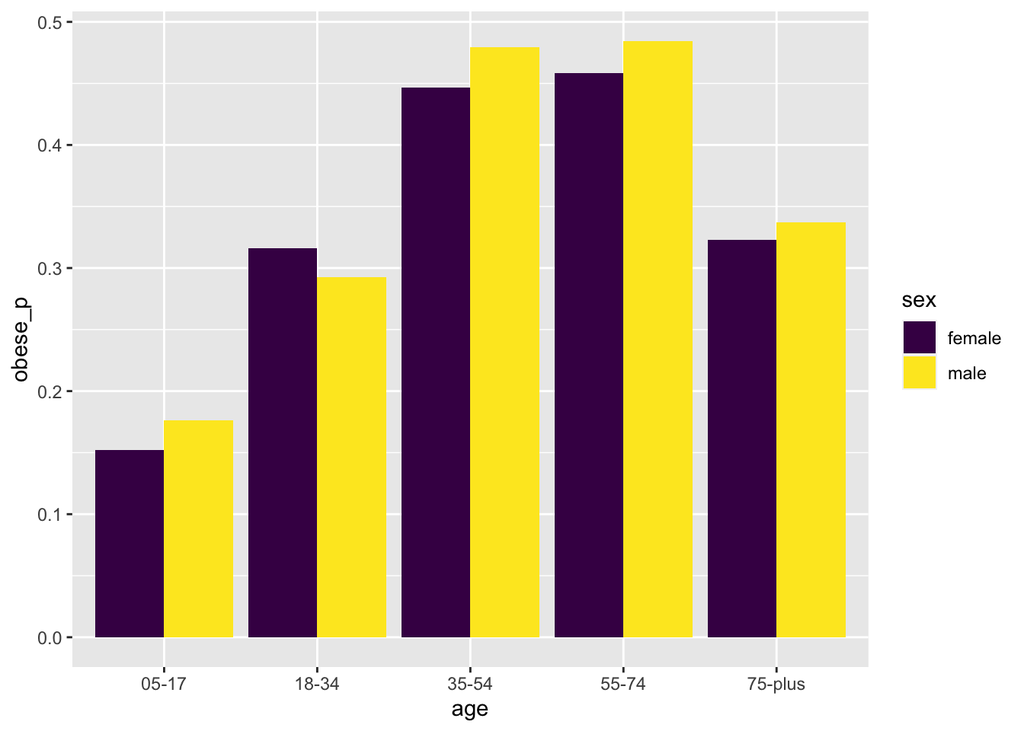

```r
obesity %>%
  group_by(age,sex) %>%
  select(obese_n,pop) %>%
  drop_na() %>%
  summarize(obese_p = sum(obese_n)/sum(pop)) %>%
  ungroup() %>%
  ggplot(aes(x = age, y = obese_p, fill = sex)) +
  geom_col(position = "dodge")
```

# Lecture: Explore Relationship Between Obesity and Rural/Urban Environments

### Summarize Rural/Urban

> What fraction of adults live in rural and urban parts of Wisconsin?

> How do the obesity rates compare between these two populations?

### Compare Obesity among Rural/Urban areas

> What fraction of adults live in rural and urban parts of Wisconsin?

```r
ru <- obesity %>%
  select(zip,rural,urban,population) %>%
  distinct()

ru %>%
  summarize(total_r = sum(rural),
            total_u = sum(urban),
            total = sum(population),
            p_rural = total_r/total,
            p_urban = total_u/total)
```

```
## # A tibble: 1 x 5
##   total_r total_u   total p_rural p_urban
##     <dbl>   <dbl>   <dbl>   <dbl>   <dbl>
## 1 1697374 3989638 5687012   0.298   0.702
```

The rural/urban data does not distinguish among children and adults. About 30% of Wisconsin residents live in rural areas and about 70% live in urban areas.

> How do the obesity rates compare between these two populations? Explore numerically and graphically.

```r
ru2 <- obesity %>%
  filter(adult == TRUE) %>%
  select(zip,obese,bmi,pop,sex,age,rural,urban,population) %>%
  drop_na() %>%
  mutate(obese_n = obese/bmi*pop,
         obese_p = obese/bmi,
         non_obese_n = pop - obese_n,
         p_rural = rural/population,
         p_urban = urban/population,
         obese_r = obese_n * p_rural,
         obese_u = obese_n * p_urban,
         non_obese_r = non_obese_n * p_rural,
         non_obese_u = non_obese_n * p_urban)

ru2 %>%
  select(obese_r,obese_u,non_obese_r,non_obese_u) %>%
  summarize_all(sum) %>%
  summarize(prevalence_r = round(obese_r/(obese_r + non_obese_r),3),
            prevalence_u = round(obese_u/(obese_u + non_obese_u),3))
```

```
## # A tibble: 1 x 2
##   prevalence_r prevalence_u
##          <dbl>        <dbl>
## 1        0.448        0.398
```

The obesity rate among adults in rural Wisconsin is about 45% and it is about 40% in urban Wisconsin.

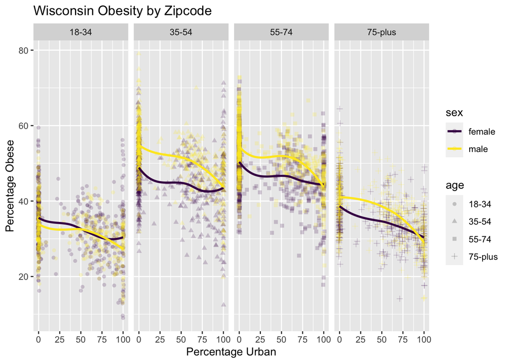

```r
ggplot(ru2, aes(x=100*p_urban,y=100*obese_p,color=sex,shape=age)) +
  geom_point(position = position_jitter(width=1,height=0), alpha=0.2) +
  geom_smooth(se=FALSE) +
  xlab("Percentage Urban") +
  ylab("Percentage Obese") +
  ggtitle("Wisconsin Obesity by Zipcode") +
  facet_grid(. ~ age)
```

Observations:

- As zip code regions become more urban, the observed prevalence of obesity decreases in every age range for both males and females
- There is considerable variation in obesity rates by zip code even at similar rural/urban mixes.
- Obesity rates are higher in the age ranges from 35-54 and 55-74 than 18-34 or 75 and older among both men and women.
- One plausible explanation for the lower observed obesity rate among adults aged 75 and older is a higher mortality rate among obese individuals from age 55-74.

# Lecture: Graphing Obesity Data on a Map

## Obesity by Zip Code

```r
obesity1 <- obesity %>%
  filter(adult) %>%
  select(zip,obese_n,pop) %>%
  drop_na() %>%
  group_by(zip) %>%
  summarize(obese_pct = 100*sum(obese_n) / sum(pop))
```

### Latitude and longitude

Load the latitude and longitude of each zip code from the `wi_zip.csv` file and join with our `obesity1`.

```r
wi_zip <- read_csv("../../data/wi_zip.csv") %>%
  mutate(zip = as.character(zip))

obesity1 <- obesity1 %>%
  left_join(wi_zip, by="zip")
```

### Plot

We will use functions in the `ggmap` and `mapproj` packages to plot an outline of the state of Wisconsin. From `map_data` we can get the data for the boundary of the state. Then, we can overlay this with a layer of points.

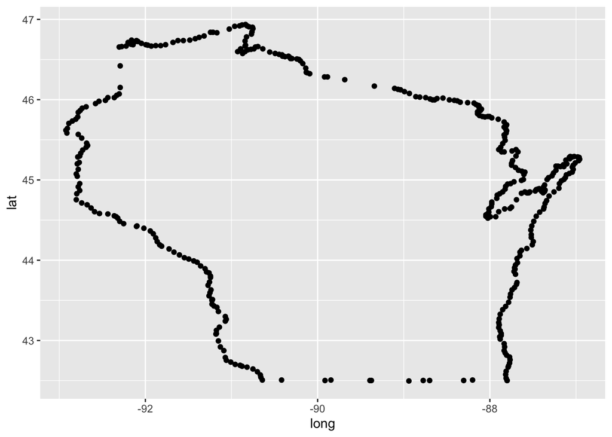

```r
library(ggmap)
library(mapproj)

wi <- map_data('state',region='wisconsin')

# Data from `wi`
ggplot() +
  geom_point(data=wi,
               mapping=aes(x=long,y=lat),
               fill="white",
               color="black")
```

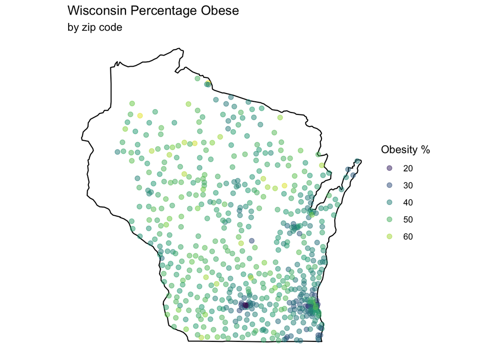

```r
ggplot() +
  geom_polygon(data=wi,
               mapping=aes(x=long,y=lat),
               fill="white",
               color="black") +
  coord_map() +
  geom_point(data=obesity1,
             mapping=aes(x=longitude,y=latitude,color=obese_pct),
             size=2,alpha=0.5) +
  guides(color = guide_legend("Obesity %")) +
  theme_void()+
  ggtitle("Wisconsin Percentage Obese",
          subtitle="by zip code")
```

## Map Rural/Urban Areas

```r
ru <- obesity %>%
  select(zip,rural,urban,population,households) %>%
  distinct() %>%
  mutate(rural_pct = 100*rural/(rural+urban)) %>%
  left_join(wi_zip, by="zip")
```

#### Map Rural

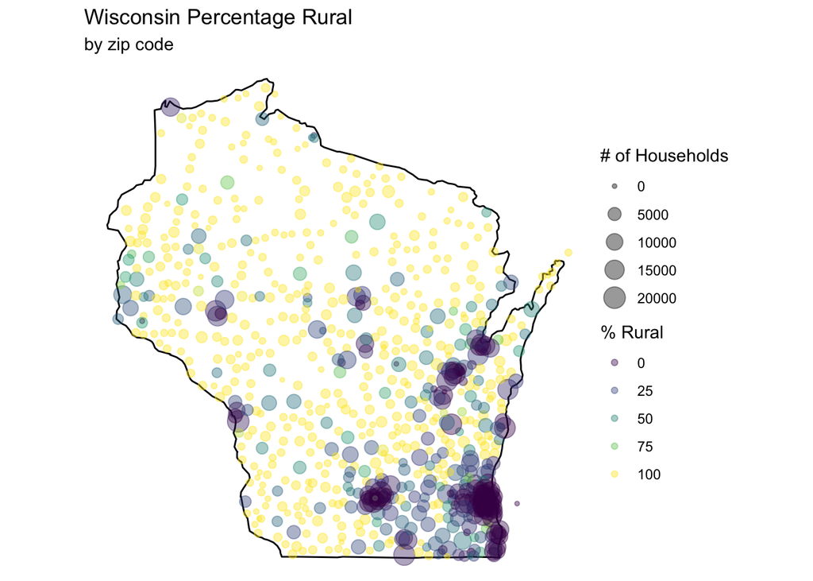

```r
ggplot() +
  geom_polygon(data=wi,
               mapping=aes(x=long,y=lat),
               fill="white",
               color="black") +
  coord_map() +
  geom_point(data=ru,
             mapping=aes(x=longitude,y=latitude,
                         color=rural_pct,size=households),
             alpha=0.4) +
  guides(color = guide_legend(title="% Rural"),
         size = guide_legend(title="# of Households")) +
  ggtitle("Wisconsin Percentage Rural",
          subtitle="by zip code") +
  theme_void()
```

## Obesity and Percentage Urban by Zip Code

```r
obesity2 <- obesity %>%
  filter(age != "05-17") %>%
  select(zip,obese_n,pop,rural,urban,population,households) %>%
  drop_na() %>%
  group_by(zip) %>%
  summarize(obese_pct = 100*sum(obese_n)/sum(pop),
            urban_pct = 100*sum(urban)/sum(population),
            households = mean(households)) %>%
  left_join(wi_zip, by="zip")
```

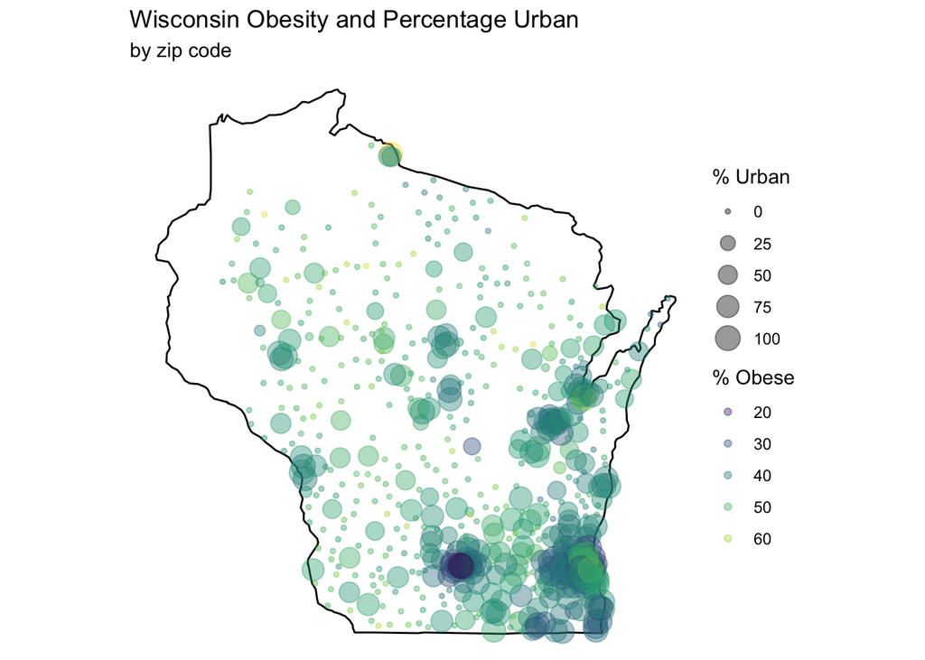

```r
ggplot() +
  geom_polygon(data=wi,
               mapping=aes(x=long,y=lat),
               fill="white",
               color="black") +
  coord_map() +
  geom_point(data=obesity2,
             mapping=aes(x=longitude,y=latitude,
                         color=obese_pct,
                         size=urban_pct),
             alpha=0.4) +
  guides(color = guide_legend(title="% Obese"),
         size = guide_legend(title="% Urban")) +
  ggtitle("Wisconsin Obesity and Percentage Urban",
          subtitle="by zip code") +
  theme_void()
```